# lab_1

# Primeira aula de laboratório, script 1[^1]

O objetivo deste roteiro de aula é apresentar comandos básicos do R, comandos necessários para estimação de uma regressão linear múltipla e introduzir a interpretação das estimativas pontuais.

## Regressões que serão estimadas

1 - Infecções por COVID-19, gênero e características socioeconômicas, âmbito internacional (Abras, Fava e Kuwahara, 2021).

infec_per_capita = $\beta_0$ + $\beta_1$dirigente_mulher + $\beta_2$fertilidade + $\beta_3$poluição + $\beta_4$lockdown + $\beta_5$ continente + u

2 - Mortalidade devido a COVID-19 e características socioeconômicas, âmbito internacional (Abras, Fava e Kuwahara, 2021)

obitos_per_capita = $\beta_0$ + $\beta_1$dirigente_mulher + $\beta_2$fertilidade + $\beta_3$poluição + $\beta_4$lockdown + $\beta_5$continente + $\beta_6$infec_per_capita + u

3 - Equação de Mincer (Giuberti e Menezes-Filho, 2005; Meara, Pastore e Webster, 2020)

salário_hora_real = $\beta_0$ + $\beta_1$educação + $\beta_2$experiência + $\beta_3$setor + $\beta_4$ocupação + $\beta_5$gênero + $\beta_6$etnia + $\beta_7$região + $\beta_8$área_urbana + u<sub>t</sub>

## Dados

```r
# install.packages("tidyverse")
library(tidyverse)
load("aulas_praticas/aula_1/lab_1_dados.Rdata")

# convertendo para tibbles

db_cov <- db_cov |> dplyr::as_tibble(db_cov)

db_min <- db_min |> dplyr::as_tibble(db_cov)

db_cov
```

| CountryCode | country | date | pop_2020 | casos_por_milhao | new_cases_per_million | obitos_por_milhao | new_deaths_per_million | sci_2017 | fem_head | airpoll_exposure_ | mort_unsafe_sanit_ | nurses_ | physicians_ | logistics_infra_ | ration_femtomale_unemp_ilo_ | vulnerableemp_fem_ | fertility_ | women_parliaments | female_labor_ratio_nat | gdp | drinkingwater | healthexp | income20up | income20low | povertygap | povertyrate | GII_2010_2018 | d_Implemented | d_lockdown | … |
| --- | --- | --- | --- | --- | --- | --- | --- | --- | --- | --- | --- | --- | --- | --- | --- | --- | --- | --- | --- | --- | --- | --- | --- | --- | --- | --- | --- | --- | --- | --- |
| ABW | Aruba | 2020-07-14 | 106766 | 983.459 | 0.000 | 28.099 | 0.000 | NA | 0 | NA | NA | NA | NA | NA | NA | NA | 1.824889 | NA | 85.42188 | 35531.2864 | 97.74830 | NA | NA | NA | NA | NA | NA | 0 | 0 | … |
| AFG | Afghanistan | 2020-07-14 | 38928341 | 885.088 | 0.103 | 25.996 | 0.051 | 37 | 0 | 61.616510 | 13.9 | 0.1701400 | 0.26797143 | 1.866885 | 131.46939 | 93.7621 | 5.303333 | 27.717000 | 24.86134 | 1743.4905 | 57.59054 | 9.526011 | NA | NA | NA | NA | 0.62255556 | 1 | 1 | … |
| AGO | Angola | 2020-07-14 | 32866268 | 15.396 | 0.000 | 0.791 | 0.000 | 40 | 0 | 33.106081 | 48.8 | 0.4075000 | 0.21460000 | 2.053810 | 98.72555 | 80.3552 | 5.905000 | 35.410000 | 87.94565 | 6396.6060 | 53.13290 | 2.626732 | 55.60000 | 3.800000 | 21.40000000 | 47.60000000 | 0.57640000 | 1 | 1 | … |
| AIA | Anguilla | 2020-07-14 | 15002 | 199.973 | 0.000 | 0.000 | 0.000 | NA | NA | NA | NA | NA | NA | NA | NA | NA | NA | NA | NA | NA | NA | NA | NA | NA | NA | NA | NA | 0 | 0 | … |
| ALB | Albania | 2020-07-14 | 2877800 | 1240.878 | 40.656 | 33.011 | 0.695 | 59 | 0 | 19.919271 | 0.2 | 4.1104600 | 1.24368000 | 2.210238 | 84.66684 | 58.7730 | 1.661111 | 21.461000 | 73.55188 | 10903.7586 | 89.61687 | NA | 40.42000 | 7.680000 | 0.24000000 | 1.42000000 | 0.25744444 | 1 | 1 | … |
| AND | Andorra | 2020-07-14 | 77265 | 11104.640 | 38.827 | 673.008 | 0.000 | NA | 0 | 11.644685 | NA | 4.3889000 | 3.66665000 | NA | NA | NA | 1.230000 | 42.130000 | NA | NA | 100.00000 | 10.068559 | NA | NA | NA | NA | NA | 0 | 0 | … |
| ARE | United Arab Emirates | 2020-07-14 | 9890400 | 5580.967 | 34.781 | 33.770 | 0.101 | 76 | 0 | 39.852101 | 0.1 | 4.1935111 | 1.95724444 | 3.888653 | 188.51700 | 0.7325 | 1.634556 | 20.500000 | 56.11118 | 62105.9272 | 96.47415 | 3.564815 | 38.20000 | 6.200000 | 0.00000000 | 0.00000000 | 0.18944444 | 1 | 1 | … |
| ARG | Argentina | 2020-07-14 | 45195777 | 2281.297 | 65.316 | 42.106 | 1.881 | 76 | 0 | 15.267052 | 0.4 | 3.1426667 | 3.78497500 | 2.829514 | 135.42638 | 17.7772 | 2.312889 | 37.801250 | 66.30574 | 19090.7113 | 98.86779 | 8.444258 | 47.02500 | 4.862500 | 0.37500000 | 0.93750000 | 0.36275000 | 1 | 1 | … |
| ARM | Armenia | 2020-07-14 | 2963234 | 10849.970 | 61.419 | 193.370 | 2.700 | 69 | 0 | 35.123335 | 0.2 | 5.3205429 | 3.10270000 | 2.354355 | 137.71590 | 43.6798 | 1.733889 | 13.154000 | 75.18242 | 7905.7690 | 99.27370 | 9.834980 | 40.27778 | 8.522222 | 0.34444444 | 1.93333333 | 0.30477778 | 1 | 1 | … |
| ATG | Antigua and Barbuda | 2020-07-14 | 97928 | 755.657 | 0.000 | 30.635 | 0.000 | 73 | 0 | 20.548552 | 0.1 | 4.5495333 | 2.95600000 | NA | NA | NA | 1.995556 | 10.861000 | NA | 21137.0923 | 96.82657 | 4.992038 | NA | NA | NA | NA | NA | 1 | 1 | … |

[output cut: 198 more lines]

```r
db_min
```

| ano | uf | cod_control | cod_serie | cod_ordem | sexo | idade | cond_dom | cond_fam | cor_raca | d_cart_ass | renda_mref_trab_pri_sref | horas_trab_pri_sref | tenure_job | idade_trab | d_afaz_dom | d_aposentado | d_pensionista | anos_educ | posi_ocup_trab_pri_sref | ativ_trab_pri_sref | ocup_trab_pri_sref | cod_censi | conjuge | estado_civil | id_pes | d_hom | d_etnia_bca_ama | d_etnia_pre_par | d_aposen | … |
| --- | --- | --- | --- | --- | --- | --- | --- | --- | --- | --- | --- | --- | --- | --- | --- | --- | --- | --- | --- | --- | --- | --- | --- | --- | --- | --- | --- | --- | --- | --- |
| 2004 | 11 | 11000015 | 2 | 1 | 2 | 27 | 1 | 1 | 8 | 4 | 460 | 38 | 1 | 14 | 3 | 4 | 3 | 8 | 4 | 1 | 7 | 1 | NA | NA | 110000150021 | 1 | 0 | 1 | 0 | … |
| 2004 | 11 | 11000015 | 2 | 3 | 4 | 25 | 3 | 3 | 8 | 4 | 460 | 38 | 1 | 10 | 1 | 4 | 3 | 0 | 4 | 1 | 7 | 1 | NA | NA | 110000150023 | 0 | 0 | 1 | 0 | … |
| 2004 | 11 | 11000015 | 3 | 1 | 2 | 32 | 1 | 1 | 2 | 4 | 400 | 44 | 0 | 7 | 3 | 4 | 3 | 2 | 4 | 3 | 8 | 1 | NA | NA | 110000150031 | 1 | 1 | 0 | 0 | … |
| 2004 | 11 | 11000015 | 4 | 3 | 4 | 23 | 3 | 3 | 2 | NA | 400 | 40 | 3 | 18 | 3 | 4 | 3 | 15 | 3 | 9 | 4 | 1 | NA | NA | 110000150043 | 0 | 1 | 0 | 0 | … |
| 2004 | 11 | 11000015 | 7 | 2 | 2 | 22 | 3 | 3 | 8 | 4 | 300 | 30 | 3 | 10 | 3 | 4 | 3 | 4 | 4 | 5 | 6 | 1 | NA | NA | 110000150072 | 1 | 0 | 1 | 0 | … |
| 2004 | 11 | 11000015 | 8 | 3 | 2 | 23 | 3 | 3 | 8 | 2 | 280 | 30 | 1 | 10 | 1 | 4 | 3 | 11 | 1 | 3 | 8 | 1 | NA | NA | 110000150083 | 1 | 0 | 1 | 0 | … |
| 2004 | 11 | 11000015 | 8 | 4 | 2 | 22 | 3 | 3 | 8 | 2 | 280 | 30 | 1 | 8 | 1 | 4 | 3 | 8 | 1 | 3 | 8 | 1 | NA | NA | 110000150084 | 1 | 0 | 1 | 0 | … |
| 2004 | 11 | 11000015 | 13 | 1 | 2 | 29 | 1 | 1 | 2 | 4 | 260 | 40 | 0 | 7 | 3 | 4 | 3 | 8 | 4 | 5 | 6 | 1 | NA | NA | 110000150131 | 1 | 1 | 0 | 0 | … |
| 2004 | 11 | 11000015 | 13 | 2 | 4 | 23 | 2 | 2 | 8 | 4 | 60 | 8 | 0 | 8 | 1 | 4 | 3 | 8 | 4 | 5 | 6 | 1 | NA | NA | 110000150132 | 0 | 0 | 1 | 0 | … |
| 2004 | 11 | 11000015 | 15 | 1 | 2 | 58 | 1 | 1 | 8 | NA | 455 | 40 | 14 | 9 | 1 | 4 | 3 | 3 | 3 | 8 | 5 | 1 | NA | NA | 110000150151 | 1 | 0 | 1 | 0 | … |

[output cut: 990 more lines]

## Preparação dos dados para equações 1 e 2

É comum, em dados socieconômicos que algumas variáveis apresentem, para algumas unidades, valores não-observados. Em sondagens com aplicação de questionário à pessoas ou empresas, é o que se tem quando a informação não é concedida, i.e., o entrevistado se recusa a responder ou a questão não se aplica (p.ex., idade dos filhos não se aplica a família sem filhos). Em dados de países, como é o caso da base db_cov, trata-se de informação não gerada pelo país (p.ex., países em situação de guerra não possuem serviços estatísticos funcionando, e, portanto, não calculam PIB e outras estatísticas).

Dados faltantes:

```r
db_cov |>
  dplyr::filter(is.na(fertility_)) |>
  dplyr::tally() |>
  dplyr::pull()
```

```
[1] 19
```

Fertilidade não observado para 19 países.

Limpando dados faltantes:

```r
db_covs <- db_cov |>
  dplyr::select(casos_por_milhao, obitos_por_milhao, fem_head, fertility_, airpoll_exposure_, d_lockdown, Continent, country) |>
  tidyr::drop_na()
```

Resumo estatístico das variáveis selecionadas:

```r
summary(db_covs)
```

```
 casos_por_milhao   obitos_por_milhao    fem_head        fertility_    airpoll_exposure_   d_lockdown
 Min.   :    1.23   Min.   :  0.000   Min.   :0.0000   Min.   :1.171   Min.   : 6.455    Min.   :0.000
 1st Qu.:  194.97   1st Qu.:  3.409   1st Qu.:0.0000   1st Qu.:1.736   1st Qu.:16.531    1st Qu.:1.000
 Median :  779.91   Median : 17.216   Median :0.0000   Median :2.254   Median :24.408    Median :1.000
 Mean   : 2265.86   Mean   : 67.311   Mean   :0.1124   Mean   :2.807   Mean   :28.531    Mean   :0.764
 3rd Qu.: 2690.78   3rd Qu.: 59.128   3rd Qu.:0.0000   3rd Qu.:3.786   3rd Qu.:35.498    3rd Qu.:1.000
 Max.   :36103.38   Max.   :844.463   Max.   :1.0000   Max.   :7.253   Max.   :98.248    Max.   :1.000

     Continent                 country
 Africa   :52   Afghanistan        :  1
 Asia     :44   Albania            :  1
 Europe   :40   Algeria            :  1
 NorthAmer:25   Andorra            :  1
 Oceania  : 5   Angola             :  1
 SouthAmer:12   Antigua and Barbuda:  1
                (Other)            :172
```

Gráfico de dispersão de mortalidade vs infecções:

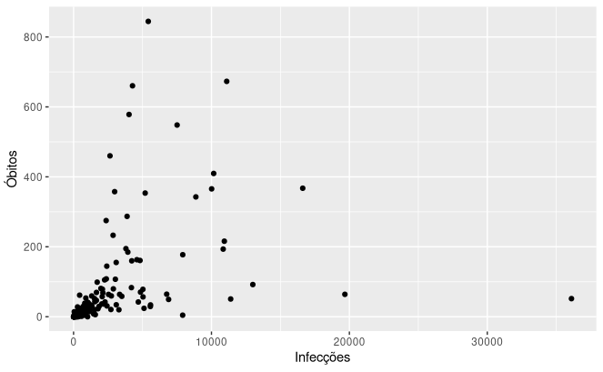

```r
db_covs |>
  ggplot() +
  geom_point(aes(
    x = casos_por_milhao,
    y = obitos_por_milhao,
  )) +
  labs(
    x = "Infecções",
    y = "Óbitos"
  )
```

Qual é a direção da relação entre as duas variáveis?

Coeficientes de correlação com teste de significância: mortalidade vs infecções:

```r
# install.packages("broom")
library(broom) # converte as funções estatísticas do R em tidy data

db_covs |> dplyr::do(
  cor.test(.$casos_por_milhao, .$obitos_por_milhao) |>
    broom::tidy()
  ) # do() executa qualquer função (fora do tidyverse) envolvendo dataframes em um pipe.
```

| estimate | statistic | p.value | parameter | conf.low | conf.high | method | alternative |
| --- | --- | --- | --- | --- | --- | --- | --- |
| 0.4198294 | 6.136676 | 5.425474e-09 | 176 | 0.2906952 | 0.5339428 | Pearson's product-moment correlation | two.sided |

A correlação é estatisticamente significativa ou não? Há contradição com o gráfico de dispersão? *R: É significativa e coerente com o gráfico.*

### Estatísticas-resumo por continente

```r
db_covs |>
  dplyr::group_by(Continent) |>
  dplyr::summarise(m_obitos_por_milhao = mean(obitos_por_milhao)) |>
  dplyr::arrange(m_obitos_por_milhao) |>
  knitr::kable(col.names = c("Continente","Óbitos por milhão"))
```

| Continente | Óbitos por milhão |
| --- | --- |
| Oceania | 7.68420 |
| Africa | 10.88904 |
| Asia | 26.57332 |
| NorthAmer | 72.24140 |
| SouthAmer | 144.98367 |
| Europe | 166.54235 |

Taxa média de letalidade: qual continente apresentou maior taxa de letalidade? A taxa de letalidade é uma medida da gravidade do impacto na saúde causado pelo COVID-19 ou do grau de risco de vida imposto pela aquisição do vírus.

```r
db_covs <- db_covs |>
  dplyr::mutate(letalidade = obitos_por_milhao/casos_por_milhao) # criando coluna com dados de letalidade

db_covs |>
  dplyr::group_by(Continent) |>
  dplyr::summarise(m_letalidade = mean(100*letalidade)) |>
  dplyr::arrange(m_letalidade) |>
  knitr::kable(col.names = c("Continente", "Taxa de letalidade (%)"),
               digits = 2)
```

| Continente | Taxa de letalidade (%) |
| --- | --- |
| Oceania | 0.91 |
| Asia | 2.16 |
| Africa | 2.37 |
| SouthAmer | 3.27 |
| NorthAmer | 3.62 |
| Europe | 5.22 |

É o que esperávamos? Qual é a razão da diferençara do ranque comparando às outras classificações? *R: Provavelmente diferenças populacionais entre os continentes.*

Os percentis da distribuição empírica de uma variável permitem identificar valores discrepantes da tendência central (média), i.e., muito pequenos ou muito grandes.

```r
db_covs |>
  dplyr::summarise(letalidade = obitos_por_milhao/casos_por_milhao) |>
  dplyr::do(
    quantile(.$letalidade, 1:20/20) |>
    broom::tidy()
  ) |>
  knitr::kable(col.names = c("Percentil", "Letalidade")) # Os valores da coluna "Letalidade" representam a distribuição da letalidade pelos percentis.
```

| Percentil | Letalidade |
| --- | --- |
| 5% | 0.0000000 |
| 10% | 0.0019993 |
| 15% | 0.0046646 |
| 20% | 0.0071230 |
| 25% | 0.0098918 |
| 30% | 0.0133748 |
| 35% | 0.0159819 |
| 40% | 0.0179539 |
| 45% | 0.0191344 |
| 50% | 0.0219203 |
| 55% | 0.0253701 |
| 60% | 0.0276922 |
| 65% | 0.0319813 |
| 70% | 0.0375119 |
| 75% | 0.0412992 |
| 80% | 0.0469252 |
| 85% | 0.0513218 |
| 90% | 0.0602842 |
| 95% | 0.0870454 |
| 100% | 0.2830463 |

Detectando outliers (países que estão nos percentis 5% e 95%):

```r
db_covs |>
  dplyr::filter(letalidade == 0) |>
  dplyr::do(
   summary(.$Continent) |>
     broom::tidy()
  ) |>
  knitr::kable(col.names = c("Continente", "Frequência"),
               caption = "Número de países abaixo do percentil 5%")
```

Número de países abaixo do percentil 5%

| Continente | Frequência |
| --- | --- |
| Africa | 3 |
| Asia | 6 |
| Europe | 0 |
| NorthAmer | 4 |
| Oceania | 2 |
| SouthAmer | 0 |

```r
db_covs |>
  dplyr::filter(letalidade >= 0.087045428) |>
  dplyr::do(
   summary(.$Continent) |>
     broom::tidy()
  ) |>
    knitr::kable(col.names = c("Continente", "Frequência"),
               caption = "Número de países acima do percentil 95%")
```

Número de países acima do percentil 95%

| Continente | Frequência |
| --- | --- |
| Africa | 0 |
| Asia | 1 |
| Europe | 6 |
| NorthAmer | 2 |
| Oceania | 0 |
| SouthAmer | 0 |

É o que esperávamos? Qual a característica de geografia física mais recorrente nesse grupo de países? *R: São ilhas.*

Quais são os países com letalidade muito alta? *R: Os continentais.*

É o que esperávamos? O que isso nos diz sobre o ranque continental?

## Preparação dos dados para equação 3

```r
db_min <- db_min |>
  dplyr::select(sal_hor,anos_educ, exper_idade_trab, exper_idade_trab_sq, d_etnia_bca_ama, d_etnia_pre_par, d_hom, d_ativ_agro, d_ativ_indus, d_ativ_const, d_ativ_social, d_ativ_serv, d_ativ_apub, d_ocup_adm, d_ocup_agro, d_ocup_com, d_ocup_serv, d_ocup_dirigente, d_ocup_cie_art, d_ocup_tec_med, d_ocup_rep_manut, d_ocup_armada, d_reg_2, d_reg_3, d_reg_4, d_reg_5, d_urbano, ano) |>
  tidyr::drop_na()
```

Salário-hora vs educação:

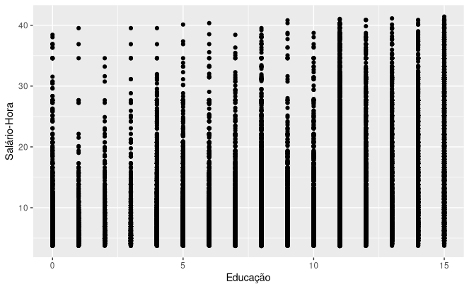

```r
sal_hor_educ <- db_min |>
  dplyr::select(anos_educ,sal_hor,ano) |>
  dplyr::filter(ano == 2015)

sal_hor_educ |>
  ggplot() +
  geom_point(aes(
    x = anos_educ,
    y = sal_hor,
  )) +
  labs(
    x = "Educação",
    y = "Salário-Hora"
  )
```

Esse gráfico de dispersão é peculiar por conta do caráter discreto da variável no eixo horizontal. Para tornar mais notória a presença (ou não) de uma relação funcional entre as duas variáveis é útil incluir o gráfico da função empírica de expectativa condicional.

```r
sal_hor_byeduc <- db_min |>
  dplyr::group_by(anos_educ) |>
  dplyr::summarise(sal_hor = mean(sal_hor))

sal_hor_byeduc
```

| anos_educ | sal_hor |
| --- | --- |
| 0 | 5.083550 |
| 1 | 5.113777 |
| 2 | 5.127647 |
| 3 | 5.429252 |
| 4 | 5.932173 |
| 5 | 6.036824 |
| 6 | 6.199076 |
| 7 | 6.220135 |
| 8 | 6.987508 |
| 9 | 6.286191 |

[output cut: 6 more lines]

Qual é a relação revelada pela FEC empírica? *R: Correlação positiva entre anos de estudo e aumento médio do salário.*

Agora, acrescentando a FEC empírica no gráfico de dispersão, tem-se:

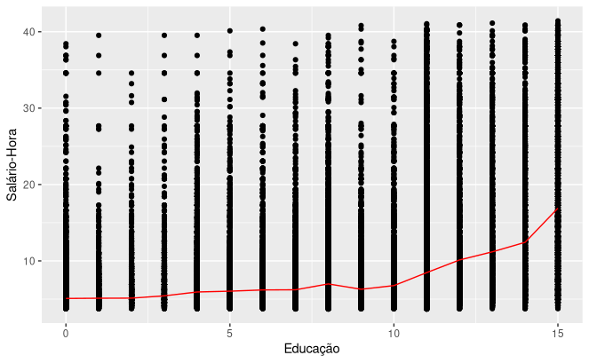

```r
sal_hor_educ |>
  ggplot() +
  geom_point(aes(
    x = anos_educ,
    y = sal_hor
    )
  ) +
  geom_line(
    data = sal_hor_byeduc,
    aes(
    x = anos_educ,
    y = sal_hor,
  ),
  color = "red") +
  labs(
    x = "Educação",
    y = "Salário-Hora"
  )
```

Coeficientes de correlação com teste de significância:

```r
db_min |> dplyr::do(
  cor.test(.$anos_educ, .$sal_hor) |>
    broom::tidy()
  )
```

| estimate | statistic | p.value | parameter | conf.low | conf.high | method | alternative |
| --- | --- | --- | --- | --- | --- | --- | --- |
| 0.4396695 | 210.2481 | 0 | 184467 | 0.4359809 | 0.4433434 | Pearson's product-moment correlation | two.sided |

Está de acordo com o gráfico? *R: Sim, o teste é significante e a correlação, embora não seja forte, é relevante.*

## Regressões

### Regressão 1

Variável dependente:

- Infecções per capita (por um milhão de habitantes) - casos_por_milhao

Variáveis explicativas:

- Instituições:
  - País é presidido ou dirigido por mulher - fem_head
- Demografia:
  - Taxa de fertilidade - fertility_ (uma proxy para a capacidade de renovação da população e, pois, juventude da população)
- Outras causas de doenças:
  - Exposição à poluição atmosférica - airpoll_exposure_
- Políticas anti-COVID:
  - Lockdown foi implementado - d_lockdown
  - Continente - Continent_

Criando *dummies*:

```r
# install.packages("fastDummies")
library("fastDummies")

db_covs <- db_covs |>
  fastDummies::dummy_columns(select_columns = "Continent",
                             remove_first_dummy = T, # criando n-1 dummies
                             remove_selected_columns = T) # removendo a coluna que gerou as dummies
db_covs # a dummie para a África foi tomada por base
```

| casos_por_milhao | obitos_por_milhao | fem_head | fertility_ | airpoll_exposure_ | d_lockdown | country | letalidade | Continent_Asia | Continent_Europe | Continent_NorthAmer | Continent_Oceania | Continent_SouthAmer |
| --- | --- | --- | --- | --- | --- | --- | --- | --- | --- | --- | --- | --- |
| 885.088 | 25.996 | 0 | 5.303333 | 61.616510 | 1 | Afghanistan | 0.0293710908 | 1 | 0 | 0 | 0 | 0 |
| 15.396 | 0.791 | 0 | 5.905000 | 33.106081 | 1 | Angola | 0.0513769810 | 0 | 0 | 0 | 0 | 0 |
| 1240.878 | 33.011 | 0 | 1.661111 | 19.919271 | 1 | Albania | 0.0266029376 | 0 | 1 | 0 | 0 | 0 |
| 11104.640 | 673.008 | 0 | 1.230000 | 11.644685 | 0 | Andorra | 0.0606060169 | 0 | 1 | 0 | 0 | 0 |
| 5580.967 | 33.770 | 0 | 1.634556 | 39.852101 | 1 | United Arab Emirates | 0.0060509227 | 1 | 0 | 0 | 0 | 0 |
| 2281.297 | 42.106 | 0 | 2.312889 | 15.267052 | 1 | Argentina | 0.0184570444 | 0 | 0 | 0 | 0 | 1 |
| 10849.970 | 193.370 | 0 | 1.733889 | 35.123335 | 1 | Armenia | 0.0178221691 | 1 | 0 | 0 | 0 | 0 |
| 755.657 | 30.635 | 0 | 1.995556 | 20.548552 | 1 | Antigua and Barbuda | 0.0405408803 | 0 | 0 | 1 | 0 | 0 |
| 391.374 | 4.235 | 0 | 1.849667 | 9.771093 | 1 | Australia | 0.0108208517 | 0 | 0 | 0 | 1 | 0 |
| 2093.955 | 78.611 | 0 | 1.461111 | 13.885195 | 1 | Austria | 0.0375418765 | 0 | 1 | 0 | 0 | 0 |

[output cut: 168 more lines]

Regressão:

```r
summary(db_covs)
```

```
 casos_por_milhao   obitos_por_milhao    fem_head        fertility_    airpoll_exposure_
 Min.   :    1.23   Min.   :  0.000   Min.   :0.0000   Min.   :1.171   Min.   : 6.455
 1st Qu.:  194.97   1st Qu.:  3.409   1st Qu.:0.0000   1st Qu.:1.736   1st Qu.:16.531
 Median :  779.91   Median : 17.216   Median :0.0000   Median :2.254   Median :24.408
 Mean   : 2265.86   Mean   : 67.311   Mean   :0.1124   Mean   :2.807   Mean   :28.531
 3rd Qu.: 2690.78   3rd Qu.: 59.128   3rd Qu.:0.0000   3rd Qu.:3.786   3rd Qu.:35.498
 Max.   :36103.38   Max.   :844.463   Max.   :1.0000   Max.   :7.253   Max.   :98.248

   d_lockdown                   country      letalidade       Continent_Asia
 Min.   :0.000   Afghanistan        :  1   Min.   :0.000000   Min.   :0.0000
 1st Qu.:1.000   Albania            :  1   1st Qu.:0.009892   1st Qu.:0.0000
 Median :1.000   Algeria            :  1   Median :0.021920   Median :0.0000
 Mean   :0.764   Andorra            :  1   Mean   :0.031542   Mean   :0.2472
 3rd Qu.:1.000   Angola             :  1   3rd Qu.:0.041299   3rd Qu.:0.0000
 Max.   :1.000   Antigua and Barbuda:  1   Max.   :0.283046   Max.   :1.0000
                 (Other)            :172
 Continent_Europe Continent_NorthAmer Continent_Oceania Continent_SouthAmer
 Min.   :0.0000   Min.   :0.0000      Min.   :0.00000   Min.   :0.00000
 1st Qu.:0.0000   1st Qu.:0.0000      1st Qu.:0.00000   1st Qu.:0.00000
 Median :0.0000   Median :0.0000      Median :0.00000   Median :0.00000
 Mean   :0.2247   Mean   :0.1404      Mean   :0.02809   Mean   :0.06742
 3rd Qu.:0.0000   3rd Qu.:0.0000      3rd Qu.:0.00000   3rd Qu.:0.00000
 Max.   :1.0000   Max.   :1.0000      Max.   :1.00000   Max.   :1.00000
```

```r
# install.packages("estimatr")
library("estimatr")

mqo_1 <- estimatr::lm_robust(casos_por_milhao ~ fem_head + fertility_ + airpoll_exposure_ + d_lockdown + Continent_Asia + Continent_Europe + Continent_NorthAmer + Continent_Oceania + Continent_SouthAmer,
                    data = db_covs)

summary(mqo_1)
```

```
Call:
estimatr::lm_robust(formula = casos_por_milhao ~ fem_head + fertility_ +
    airpoll_exposure_ + d_lockdown + Continent_Asia + Continent_Europe +
    Continent_NorthAmer + Continent_Oceania + Continent_SouthAmer,
    data = db_covs)

Standard error type:  HC2

Coefficients:
                    Estimate Std. Error  t value Pr(>|t|) CI Lower CI Upper  DF
(Intercept)          3777.95    1396.32  2.70564  0.00752  1021.35   6534.5 168
fem_head            -1162.78     783.22 -1.48462  0.13952 -2709.01    383.4 168
fertility_          -1097.84     424.25 -2.58774  0.01051 -1935.38   -260.3 168
airpoll_exposure_      73.39      50.64  1.44937  0.14910   -26.58    173.4 168
d_lockdown          -1264.61     735.57 -1.71921  0.08742 -2716.77    187.6 168
Continent_Asia        593.63     664.30  0.89362  0.37280  -717.81   1905.1 168
Continent_Europe     1020.64     818.12  1.24754  0.21394  -594.49   2635.8 168
Continent_NorthAmer    29.59     891.52  0.03319  0.97356 -1730.44   1789.6 168
Continent_Oceania     -23.81     899.17 -0.02648  0.97891 -1798.95   1751.3 168
Continent_SouthAmer  2865.73    1462.25  1.95981  0.05167   -21.03   5752.5 168

Multiple R-squared:  0.1864 ,   Adjusted R-squared:  0.1428
F-statistic: 5.323 on 9 and 168 DF,  p-value: 2.152e-06
```

infec_per_capita = 3777,95 - 1162,8*Dirigente mulher - 1097,84*Fertilidade + 73,4*Poluição - 1264,61*Lockdown + 593,63*Ásia + 1020,64*Europa + 29,6*América do Norte - 23,81*Oceania + 2865,72*América do Sul

O que se pode concluir? *R: Controlando para outras variáveis, ter uma líder mulher é associado a uma redução nas infecções per capita (por um milhão de habitantes). O resultado não é significante.*

Quais variáveis possuem relação positiva com o número de infecções? *R: Poluição e as dummies Ásia, Europa, América do Norte e América do Sul.*

Quais variáveis possuem relação negativa com o número de infecções? *R: Dirigente mulher, Fertilidade, Lockdown e a dummie Oceania.*

Qual é a proporção da variação da variável dependente explicada? *R: 18,64%*

### Regressão 2

```r
mqo_2 <- estimatr::lm_robust(obitos_por_milhao ~ fem_head + fertility_ + airpoll_exposure_ + d_lockdown + Continent_Asia + Continent_Europe + Continent_NorthAmer + Continent_Oceania + Continent_SouthAmer + casos_por_milhao,
                             data = db_covs)

summary(mqo_2)
```

```
Call:
estimatr::lm_robust(formula = obitos_por_milhao ~ fem_head +
    fertility_ + airpoll_exposure_ + d_lockdown + Continent_Asia +
    Continent_Europe + Continent_NorthAmer + Continent_Oceania +
    Continent_SouthAmer + casos_por_milhao, data = db_covs)

Standard error type:  HC2

Coefficients:
                     Estimate Std. Error t value  Pr(>|t|)   CI Lower  CI Upper  DF
(Intercept)           5.99088  45.268360  0.1323 0.8948735 -8.338e+01  95.36289 167
fem_head            -17.07295  40.382844 -0.4228 0.6730017 -9.680e+01  62.65373 167
fertility_            9.14827   6.944474  1.3173 0.1895275 -4.562e+00  22.85854 167
airpoll_exposure_    -1.15310   0.547580 -2.1058 0.0367167 -2.234e+00  -0.07203 167
d_lockdown           -3.68970  23.105755 -0.1597 0.8733204 -4.931e+01  41.92732 167
Continent_Asia        4.35382  11.615877  0.3748 0.7082725 -1.858e+01  27.28671 167
Continent_Europe    132.89956  34.234067  3.8821 0.0001489  6.531e+01 200.48689 167
Continent_NorthAmer  46.20956  18.708758  2.4699 0.0145186  9.273e+00  83.14572 167
Continent_Oceania    -9.38969  15.329513 -0.6125 0.5410245 -3.965e+01  20.87492 167
Continent_SouthAmer  88.23931  34.351202  2.5687 0.0110820  2.042e+01 156.05789 167
casos_por_milhao      0.01331   0.006264  2.1248 0.0350773  9.427e-04   0.02568 167

Multiple R-squared:  0.3708 ,   Adjusted R-squared:  0.3331
F-statistic: 6.542 on 10 and 167 DF,  p-value: 1.669e-08
```

O que se pode concluir? *R: Para óbitos por milhão, as variáveis significantes são a exposição a poluição, os continentes europeu, norte-americano, sul-americano e os casos por milhão.*

Quais variáveis possuem relação positiva com o número de óbitos? *R: Taxa de fertilidade, os continentes asiático, europeu, norte-americano, sulamericano e os casos por milhão.*

Quais variáveis possuem relação negativa com o número de óbitos? *R: A liderança feminina, a exposição a poluição, o lockdown e o continente da Oceania.*

```r
cbind(óbitos=coef(mqo_2),infecções=c(coef(mqo_1),NA))
```

```
                          óbitos   infecções
(Intercept)           5.99088039  3777.94630
fem_head            -17.07294544 -1162.78354
fertility_            9.14827059 -1097.84026
airpoll_exposure_    -1.15309611    73.39331
d_lockdown           -3.68969587 -1264.60730
Continent_Asia        4.35382236   593.63094
Continent_Europe    132.89956438  1020.64098
Continent_NorthAmer  46.20955831    29.58729
Continent_Oceania    -9.38968945   -23.80919
Continent_SouthAmer  88.23931307  2865.72527
casos_por_milhao      0.01330986          NA
```

### Regressão 3

Variável dependente:

- Salário-hora

Variáveis independentes:

- Educação e experiência:
  - Anos de estudo - anos_educ
  - Experiência - exper_idade_trab (idade em que começou a trabalhar)
  - Experiência ao quadrado - exper_idade_trab_sq
- Características pessoais:
  - Etnia preta ou parda - etnia_pre_par
  - Sexo masculino - d_hom
- Setor e ocupação:
  - Setor de atividade: agropecuária, indústria, construção, educação/saúde/social, outros serviços, administração pública - d_ativ*
  - Ocupação: administração, agricultura, comércio, outros serviços, dirigente, ciência/tecnologia, técnico de nível médio, reparo/manutenção, forças armadas - d_ocup*
- Regional
  - Grande região brasileiras - Nordeste (2), Sudeste (3), Sul (4), Centro Oeste (5) - d_reg_2 a d_reg_5
  - Área urbana - d_urbano

Há a rigor dois grupos de etnia nas subamostras da PNAD consideradas, (1) brancos e amarelos e (2) pretos e pardos. Por que um deles não foi considerado? *R: Um grupo foi usado de referência para as outras dummies.*

Por que a variável experiência ao quadrado é incluída?

```r
summary(subset(db_min,select=c(anos_educ,exper_idade_trab,exper_idade_trab_sq,d_etnia_bca_ama,d_etnia_pre_par,d_hom,d_ativ_agro,d_ativ_indus,d_ativ_const,d_ativ_social,d_ativ_serv,d_ativ_apub,d_ocup_adm,d_ocup_agro,d_ocup_com,d_ocup_serv,d_ocup_dirigente,d_ocup_cie_art,d_ocup_tec_med,d_ocup_rep_manut,d_ocup_armada,d_reg_2,d_reg_3,d_reg_4,d_reg_5,d_urbano)))
```

```
   anos_educ      exper_idade_trab exper_idade_trab_sq d_etnia_bca_ama  d_etnia_pre_par
 Min.   : 0.000   Min.   : 0.0     Min.   :   0.0      Min.   :0.0000   Min.   :0.0000
 1st Qu.: 6.000   1st Qu.:10.0     1st Qu.: 100.0      1st Qu.:0.0000   1st Qu.:0.0000
 Median :11.000   Median :19.0     Median : 361.0      Median :0.0000   Median :1.0000
 Mean   : 8.917   Mean   :19.8     Mean   : 541.3      Mean   :0.4603   Mean   :0.5397
 3rd Qu.:11.000   3rd Qu.:29.0     3rd Qu.: 841.0      3rd Qu.:1.0000   3rd Qu.:1.0000
 Max.   :15.000   Max.   :59.0     Max.   :3481.0      Max.   :1.0000   Max.   :1.0000
     d_hom         d_ativ_agro       d_ativ_indus     d_ativ_const     d_ativ_social     d_ativ_serv
 Min.   :0.0000   Min.   :0.00000   Min.   :0.0000   Min.   :0.00000   Min.   :0.0000   Min.   :0.0000
 1st Qu.:0.0000   1st Qu.:0.00000   1st Qu.:0.0000   1st Qu.:0.00000   1st Qu.:0.0000   1st Qu.:0.0000
 Median :1.0000   Median :0.00000   Median :0.0000   Median :0.00000   Median :0.0000   Median :0.0000
 Mean   :0.5571   Mean   :0.06467   Mean   :0.1561   Mean   :0.06236   Mean   :0.1419   Mean   :0.3978
 3rd Qu.:1.0000   3rd Qu.:0.00000   3rd Qu.:0.0000   3rd Qu.:0.00000   3rd Qu.:0.0000   3rd Qu.:1.0000
 Max.   :1.0000   Max.   :1.00000   Max.   :1.0000   Max.   :1.00000   Max.   :1.0000   Max.   :1.0000
  d_ativ_apub        d_ocup_adm      d_ocup_agro        d_ocup_com       d_ocup_serv
 Min.   :0.00000   Min.   :0.0000   Min.   :0.00000   Min.   :0.00000   Min.   :0.0000
 1st Qu.:0.00000   1st Qu.:0.0000   1st Qu.:0.00000   1st Qu.:0.00000   1st Qu.:0.0000
 Median :0.00000   Median :0.0000   Median :0.00000   Median :0.00000   Median :0.0000
 Mean   :0.08077   Mean   :0.1408   Mean   :0.06216   Mean   :0.07714   Mean   :0.2611
 3rd Qu.:0.00000   3rd Qu.:0.0000   3rd Qu.:0.00000   3rd Qu.:0.00000   3rd Qu.:1.0000
 Max.   :1.00000   Max.   :1.0000   Max.   :1.00000   Max.   :1.00000   Max.   :1.0000
 d_ocup_dirigente  d_ocup_cie_art    d_ocup_tec_med   d_ocup_rep_manut d_ocup_armada
 Min.   :0.00000   Min.   :0.00000   Min.   :0.0000   Min.   :0.0000   Min.   :0.00000
 1st Qu.:0.00000   1st Qu.:0.00000   1st Qu.:0.0000   1st Qu.:0.0000   1st Qu.:0.00000
 Median :0.00000   Median :0.00000   Median :0.0000   Median :0.0000   Median :0.00000
 Mean   :0.03126   Mean   :0.08068   Mean   :0.0919   Mean   :0.2399   Mean   :0.01473
 3rd Qu.:0.00000   3rd Qu.:0.00000   3rd Qu.:0.0000   3rd Qu.:0.0000   3rd Qu.:0.00000
 Max.   :1.00000   Max.   :1.00000   Max.   :1.0000   Max.   :1.0000   Max.   :1.00000
    d_reg_2          d_reg_3          d_reg_4          d_reg_5          d_urbano
 Min.   :0.0000   Min.   :0.0000   Min.   :0.0000   Min.   :0.0000   Min.   :0.0000
 1st Qu.:0.0000   1st Qu.:0.0000   1st Qu.:0.0000   1st Qu.:0.0000   1st Qu.:1.0000
 Median :0.0000   Median :0.0000   Median :0.0000   Median :0.0000   Median :1.0000
 Mean   :0.2443   Mean   :0.3324   Mean   :0.1763   Mean   :0.1211   Mean   :0.9086
 3rd Qu.:0.0000   3rd Qu.:1.0000   3rd Qu.:0.0000   3rd Qu.:0.0000   3rd Qu.:1.0000
 Max.   :1.0000   Max.   :1.0000   Max.   :1.0000   Max.   :1.0000   Max.   :1.0000
```

#### Modelo em 2004

```r
db_min_2004 <- db_min |> filter(ano == 2004)

mqo_3 <- estimatr::lm_robust(sal_hor ~ anos_educ + exper_idade_trab + exper_idade_trab_sq + d_etnia_pre_par + d_hom + d_ativ_agro + d_ativ_indus + d_ativ_const + d_ativ_social + d_ativ_serv + d_ativ_apub + d_ocup_adm + d_ocup_agro + d_ocup_com + d_ocup_serv + d_ocup_dirigente + d_ocup_cie_art + d_ocup_tec_med + d_ocup_rep_manut + d_ocup_armada + d_reg_2 + d_reg_3 + d_reg_4 + d_reg_5 + d_urbano,
                             data = db_min_2004)

summary(mqo_3)
```

```
Call:
estimatr::lm_robust(formula = sal_hor ~ anos_educ + exper_idade_trab +
    exper_idade_trab_sq + d_etnia_pre_par + d_hom + d_ativ_agro +
    d_ativ_indus + d_ativ_const + d_ativ_social + d_ativ_serv +
    d_ativ_apub + d_ocup_adm + d_ocup_agro + d_ocup_com + d_ocup_serv +
    d_ocup_dirigente + d_ocup_cie_art + d_ocup_tec_med + d_ocup_rep_manut +

Standard error type:  HC2

Coefficients:
                     Estimate Std. Error  t value   Pr(>|t|)  CI Lower CI Upper    DF
(Intercept)          0.211173  5.996e-01   0.3522  7.247e-01 -0.964071  1.38642 93080
anos_educ            0.369292  4.467e-03  82.6687  0.000e+00  0.360537  0.37805 93080
exper_idade_trab     0.203126  3.440e-03  59.0400  0.000e+00  0.196383  0.20987 93080
exper_idade_trab_sq -0.002572  7.263e-05 -35.4160 6.413e-273 -0.002715 -0.00243 93080
d_etnia_pre_par     -0.635605  2.735e-02 -23.2394 3.987e-119 -0.689212 -0.58200 93080
d_hom                1.099752  3.021e-02  36.3988 4.772e-288  1.040533  1.15897 93080
d_ativ_agro         -1.509214  1.387e-01 -10.8843  1.422e-27 -1.780985 -1.23744 93080
d_ativ_indus        -0.331888  6.370e-02  -5.2105  1.887e-07 -0.456732 -0.20704 93080
d_ativ_const        -0.920635  7.252e-02 -12.6947  6.790e-37 -1.062776 -0.77849 93080
d_ativ_social       -0.170503  6.873e-02  -2.4807  1.312e-02 -0.305219 -0.03579 93080
d_ativ_serv         -0.747256  5.217e-02 -14.3233  1.755e-46 -0.849510 -0.64500 93080
d_ativ_apub          0.701980  8.140e-02   8.6241  6.561e-18  0.542441  0.86152 93080
d_ocup_adm           0.540480  5.936e-01   0.9105  3.626e-01 -0.622990  1.70395 93080
d_ocup_agro         -0.210188  6.061e-01  -0.3468  7.287e-01 -1.398082  0.97771 93080
d_ocup_com          -0.537824  5.940e-01  -0.9054  3.653e-01 -1.702143  0.62650 93080
d_ocup_serv         -0.783525  5.933e-01  -1.3207  1.866e-01 -1.946321  0.37927 93080
d_ocup_dirigente     4.071856  6.032e-01   6.7507  1.480e-11  2.889645  5.25407 93080
d_ocup_cie_art       4.620925  5.988e-01   7.7165  1.208e-14  3.447209  5.79464 93080
d_ocup_tec_med       2.171228  5.953e-01   3.6470  2.654e-04  1.004371  3.33808 93080
d_ocup_rep_manut    -0.137929  5.933e-01  -0.2325  8.162e-01 -1.300730  1.02487 93080
d_ocup_armada        3.174582  6.139e-01   5.1714  2.328e-07  1.971404  4.37776 93080
d_reg_2             -0.675888  4.211e-02 -16.0488  6.969e-58 -0.758432 -0.59334 93080
d_reg_3              0.553537  4.249e-02  13.0286  9.095e-39  0.470264  0.63681 93080
d_reg_4              0.425690  4.928e-02   8.6389  5.764e-18  0.329110  0.52227 93080
d_reg_5              0.567452  5.179e-02  10.9559  6.477e-28  0.465935  0.66897 93080
d_urbano             0.439815  3.847e-02  11.4317  3.042e-30  0.364408  0.51522 93080

Multiple R-squared:  0.3932 ,   Adjusted R-squared:  0.393
F-statistic:  1679 on 25 and 93080 DF,  p-value: < 2.2e-16
```

#### Modelo em 2015

```r
db_min_2015 <- db_min |> filter(ano == 2015)

mqo_4 <- estimatr::lm_robust(sal_hor ~ anos_educ + exper_idade_trab + exper_idade_trab_sq + d_etnia_pre_par + d_hom + d_ativ_agro + d_ativ_indus + d_ativ_const + d_ativ_social + d_ativ_serv + d_ativ_apub + d_ocup_adm + d_ocup_agro + d_ocup_com + d_ocup_serv + d_ocup_dirigente + d_ocup_cie_art + d_ocup_tec_med + d_ocup_rep_manut + d_ocup_armada + d_reg_2 + d_reg_3 + d_reg_4 + d_reg_5 + d_urbano,
                             data = db_min_2015)

summary(mqo_4)
```

```
Call:
estimatr::lm_robust(formula = sal_hor ~ anos_educ + exper_idade_trab +
    exper_idade_trab_sq + d_etnia_pre_par + d_hom + d_ativ_agro +
    d_ativ_indus + d_ativ_const + d_ativ_social + d_ativ_serv +
    d_ativ_apub + d_ocup_adm + d_ocup_agro + d_ocup_com + d_ocup_serv +
    d_ocup_dirigente + d_ocup_cie_art + d_ocup_tec_med + d_ocup_rep_manut +

Standard error type:  HC2

Coefficients:
                     Estimate Std. Error  t value   Pr(>|t|)   CI Lower  CI Upper    DF
(Intercept)          4.760809  3.4913990   1.3636  1.727e-01  -2.082298 11.603916 91337
anos_educ            0.425104  0.0064237  66.1775  0.000e+00   0.412514  0.437695 91337
exper_idade_trab     0.235750  0.0049013  48.0993  0.000e+00   0.226144  0.245357 91337
exper_idade_trab_sq -0.002856  0.0001059 -26.9569 2.005e-159  -0.003064 -0.002648 91337
d_etnia_pre_par     -0.734899  0.0399967 -18.3740  2.902e-75  -0.813293 -0.656506 91337
d_hom                1.387741  0.0433459  32.0155 1.159e-223   1.302784  1.472699 91337
d_ativ_agro         -0.051992  0.2481481  -0.2095  8.340e-01  -0.538360  0.434376 91337
d_ativ_indus        -0.117362  0.0861435  -1.3624  1.731e-01  -0.286202  0.051478 91337
d_ativ_const        -0.042298  0.0966922  -0.4374  6.618e-01  -0.231814  0.147218 91337
d_ativ_social       -0.351473  0.0881883  -3.9855  6.740e-05  -0.524321 -0.178625 91337
d_ativ_serv         -0.612107  0.0660420  -9.2684  1.928e-20  -0.741548 -0.482665 91337
d_ativ_apub          2.086567  0.1182745  17.6417  1.538e-69   1.854750  2.318384 91337
d_ocup_adm          -3.536460  3.4890335  -1.0136  3.108e-01 -10.374931  3.302010 91337
d_ocup_agro         -4.937304  3.4964517  -1.4121  1.579e-01 -11.790314  1.915706 91337
d_ocup_com          -4.392263  3.4891082  -1.2588  2.081e-01 -11.230880  2.446354 91337
d_ocup_serv         -4.369414  3.4887633  -1.2524  2.104e-01 -11.207355  2.468527 91337
d_ocup_dirigente     2.268914  3.4917777   0.6498  5.158e-01  -4.574936  9.112763 91337
d_ocup_cie_art       3.234691  3.4901663   0.9268  3.540e-01  -3.606000 10.075382 91337
d_ocup_tec_med      -1.225709  3.4895495  -0.3513  7.254e-01  -8.065191  5.613773 91337
d_ocup_rep_manut    -3.871333  3.4885850  -1.1097  2.671e-01 -10.708925  2.966258 91337
d_ocup_armada        3.574615  3.4968858   1.0222  3.067e-01  -3.279246 10.428476 91337
d_reg_2             -0.906190  0.0597721 -15.1607  7.442e-52  -1.023343 -0.789037 91337
d_reg_3              0.656714  0.0595798  11.0224  3.104e-28   0.539938  0.773489 91337
d_reg_4              0.913302  0.0694951  13.1420  2.055e-39   0.777093  1.049512 91337
d_reg_5              1.226391  0.0764888  16.0336  8.931e-58   1.076474  1.376308 91337
d_urbano             0.594744  0.0613326   9.6970  3.181e-22   0.474533  0.714956 91337

Multiple R-squared:  0.367 ,    Adjusted R-squared:  0.3668
F-statistic:  1346 on 25 and 91337 DF,  p-value: < 2.2e-16
```

#### Visualizando resultados

| term | 2004 | 2015 |
| --- | --- | --- |
| (Intercept) | 0.2111733 | 4.760809251 |
| anos_educ | 0.3692921 | 0.425104286 |
| exper_idade_trab | 0.2031260 | 0.235750044 |
| exper_idade_trab_sq | -0.0025722 | -0.002855863 |
| d_etnia_pre_par | -0.6356052 | -0.734899451 |
| d_hom | 1.0997525 | 1.387741405 |
| d_ativ_agro | -1.5092140 | -0.051992138 |
| d_ativ_indus | -0.3318884 | -0.117362087 |
| d_ativ_const | -0.9206349 | -0.042297956 |
| d_ativ_social | -0.1705035 | -0.351472974 |

[output cut: 16 more lines]

Quais variáveis possuem relação positiva com o salário horário?

```r
mincer |>
  dplyr::filter(`2004` > 0) |>
  dplyr::select(term, `2004`)
```

| term | 2004 |
| --- | --- |
| (Intercept) | 0.2111733 |
| anos_educ | 0.3692921 |
| exper_idade_trab | 0.2031260 |
| d_hom | 1.0997525 |
| d_ativ_apub | 0.7019804 |
| d_ocup_adm | 0.5404798 |
| d_ocup_dirigente | 4.0718561 |
| d_ocup_cie_art | 4.6209247 |
| d_ocup_tec_med | 2.1712278 |
| d_ocup_armada | 3.1745816 |

[output cut: 4 more lines]

```r
mincer |>
  dplyr::filter(`2015` > 0) |>
  dplyr::select(term, `2015`)
```

| term | 2015 |
| --- | --- |
| (Intercept) | 4.7608093 |
| anos_educ | 0.4251043 |
| exper_idade_trab | 0.2357500 |
| d_hom | 1.3877414 |
| d_ativ_apub | 2.0865666 |
| d_ocup_dirigente | 2.2689135 |
| d_ocup_cie_art | 3.2346906 |
| d_ocup_armada | 3.5746149 |
| d_reg_3 | 0.6567136 |
| d_reg_4 | 0.9133023 |

[output cut: 2 more lines]

Quais variáveis possuem relação negativa com o salário horário?

| term | 2015 |
| --- | --- |
| exper_idade_trab_sq | -0.002855863 |
| d_etnia_pre_par | -0.734899451 |
| d_ativ_agro | -0.051992138 |
| d_ativ_indus | -0.117362087 |
| d_ativ_const | -0.042297956 |
| d_ativ_social | -0.351472974 |
| d_ativ_serv | -0.612106530 |
| d_ocup_adm | -3.536460207 |
| d_ocup_agro | -4.937303738 |
| d_ocup_com | -4.392262767 |

[output cut: 4 more lines]

Como interpretar o coeficiente da educação? *R: Um ano a mais de educação leva a um aumento, em média, de 0,37 reais no salário-hora.*

Como interpretar o coeficiente da experiência (medida em anos)? *R: Um ano a mais de experiência leva a um aumento, em média, de 0,20 reais no salário-hora.*

Como interpretar o coeficiente da etnia preta e parda? *R: Trabalhadores pretos e pardos possuem uma diferença, em média, de -0,63 reais de salário-hora.*

Como interpretar o coeficiente do gênero masculino? *R: Homens ganham, em média, 1,1 reais de salário-hora a mais que mulheres.*

Para quais variáveis o coeficiente estimado difere entre 2004 e 2015? O retorno da educação aumentou?

| term | 2004 | 2015 | var |
| --- | --- | --- | --- |
| (Intercept) | 0.2111733 | 4.76080925 | 21.5445655 |
| anos_educ | 0.3692921 | 0.42510429 | 0.1511330 |
| exper_idade_trab | 0.2031260 | 0.23575004 | 0.1606099 |
| d_etnia_pre_par | -0.6356052 | -0.73489945 | -0.1562201 |
| d_hom | 1.0997525 | 1.38774140 | 0.2618671 |
| d_ativ_agro | -1.5092140 | -0.05199214 | 0.9655502 |
| d_ativ_indus | -0.3318884 | -0.11736209 | 0.6463809 |
| d_ativ_const | -0.9206349 | -0.04229796 | 0.9540557 |
| d_ativ_social | -0.1705035 | -0.35147297 | -1.0613829 |
| d_ativ_serv | -0.7472563 | -0.61210653 | 0.1808613 |

[output cut: 14 more lines]

*R: O retorno da educação aumentou, em média,* 15.11%.

O retorno da experiência aumentou?

```r
retorno_exp <- mincer |>
  dplyr::slice(3) |>
  dplyr::summarise(var = (`2015`-`2004`)/abs(`2004`)*100) |>
  dplyr::pull()

retorno_exp
```

```
[1] 16.06099
```

*R: O retorno da experiência aumentou, em média,* 16.06%.

Faz sentido afirmar que há diferenciação regional em salário horário? *R: Sim, pois todas as variáveis referentes às regiões brasileiras são significantes.*

# Referências

ABRAS, A.; FAVA, A. C. P. E.; KUWAHARA, M. Y. Women Heads of State and Covid-19 Policy Responses. **Feminist Economics**, v. 27, n. 1-2, p. 380–400, 3 abr. 2021.

GIUBERTI, A. C.; MENEZES-FILHO, N. Discriminação de rendimentos por gênero: uma comparação entre o Brasil e os Estados Unidos. **Economia Aplicada**, v. 9, p. 369–384, set. 2005.

MEARA, K.; PASTORE, F.; WEBSTER, A. The gender pay gap in the USA: a matching study. **Journal of Population Economics**, v. 33, n. 1, p. 271–305, 1 jan. 2020.

[^1]: Preparado por Thiago Fonseca Morello (CECS-UFABC).